# Absence of alien coniferous tree species

[NO_AATS_001]

Authors

Affiliations

Erik Framstad

Norwegian Institute for Nature Research

Ken Olav Storaunet

Norwegian Institute of Bioeconomy Research

Aud Helen Halbritter

University of Bergen

Published

October 26, 2025

> **Recommended citation**: Framstad, E., Storaunet, K.O. and Halbritter, A. H. 2025. Alien coniferous tree species (ID: NO_AATS_001) v. 000.001. ecRxiv: https://github.com/NINAnor/ecRxiv/tree/main/indicators/NO_AATS_001

**Metadata**

Table 1: Indicator metadata

| Variable | Value |
| --- | --- |
| Indicator ID | NO_AATS_001 |
| Indicator Name | Alien coniferous tree species |
| Country | Norway |
| Continent | Europe |
| Ecosystem Condition Typology Class | B1 Biotic compositional characteristic |
| Realm | Terrestrial (T) |
| Biome | T2 Temperate-boreal forests and woodlands biome |
| Ecosystem | T2.1 Boreal/montane forests |
| Year added | 2025 |
| Last update | 2025 |
| Version | 000.001 |
| Version comment | Inital version |
| Normalised | TRUE |
| Spatial aggregation pathway | Scale - aggregate (area-weighted arithmetic mean) |

**Log**

- 26 Oct. 2025 - Original PR

## 1. Summary

1. **Background and rationale**: Many non-native or alien tree species are considered to have a high or very high risk for native forest ecosystems. Intact ecosystems should not contain any such alien species of high ecological risk. This indicator is specified as the absence (0% volume) of alien coniferous tree species. Alien coniferous species represent the most abundant alien tree species considered to have a high ecological risk by Artsdatabanken (2023). Data for this indicator come from the National Forest Inventory (NFI), where all trees larger than 5 cm at breast height (dbh) have been recorded within the 250 m² NFI plots since the mid-1980s (Viken (2021)). The planting of alien tree species in forestry is the most important anthropogenic driver for this indicator.
2. **Methods**: All trees larger than 5 cm at breast height (dbh) are recorded and identified to species for each 250 m² NFI inventory plot. There are about 12,000 NFI plots in forest ecosystems, distributed on a regular grid. The indicator value is an unbiased area-weighted estimate of the proportion of alien coniferous tree species (measured as % of volume for cutting class 3-5 and % of crown cover for cutting class 2), for included NFI plots in any selected region. All NFI plots are sampled over a 5-year period, with a representative sampling scheme every year. For this indicator, data are included from the last 5 years including the reporting year, currently 2020-2024.
3. **Interpretation**: An indicator value of 1 (100% absence) signifies intact forest ecosystems where alien coniferous tree species are completely absent. Values decreasing toward zero reflect increasing presence of alien coniferous species, indicating deviation from the natural reference condition. The relationship between indicator values and ecosystem condition is assumed to be linear at this stage, though non-linear relationships may be more appropriate.
4. **Results and development needs**: The indicator is ready for use but should not be used at finer spatial resolution than counties. Development needs include: refinement of the relationship between indicator values and ecosystem condition (linear vs. non-linear), and improved quantification of uncertainties related to the setting of the lower reference value.

## 2. About the underlying data

### 2.2 Sampling design

All trees larger than 5 cm at breast height (dbh) are recorded and identified to species for each 250 m² NFI inventory plot (Viken (2021)). There are about 12,000 NFI plots in forest ecosystems, distributed on a regular grid, with varying coverage for forest below/above the coniferous forest line and in Finnmark county. All NFI plots are sampled over a 5-year period, with a representative sampling scheme every year, allowing unbiased estimates from data for each year.

### 2.3 Original units

The indicator is specified as the proportion (%) of forest stand tree volume (cutting class 3-5) or crown cover (cutting class 2) for introduced coniferous species (NFI variables introgran_pr, introfuru_pr).

### 2.4 Instructions for citing, using and accessing data

The data used for this indicator have been made available by the Norwegian National Forest Inventory under a specific data use agreement of 2025-10-20, between NIBIO and the specified users. Further use of these data requires a separate data user agreement with NIBIO.

### 2.5 Additional comments about the dataset

None

## 3. Indicator properties

### 3.1 Ecosystem Condition Typology Class (ECT)

The absence of alien species is considered an aspect of the composition of biodiversity. Hence, this indicator represents a B1 Biotic compositional characteristic.

### 3.1.1 Other condition typologies

None

### 3.2 Ecosystem condition characteristic

The absence of alien species is considered an aspect of the composition of biodiversity. The indicator represents a characteristic of Biodiversity.

### 3.3 Collinearities with other indicators

There may be some positive correlation with the indicator for the absence of alien plant species, although the latter indicator is based on species in the field layer.

### 3.4 Impact factors

Natural disturbances and long-term shifts in climate conditions may increase the opportunity for alien species to spread and get established in otherwise intact forest ecosystems. The planting of alien tree species in forestry is the most important anthropogenic driver for this indicator, although such planting has been reduced lately. Harvested alien tree species may to some extent be replaced by native species. Other planting of exotic trees in parks, gardens, as windbreaks etc will establish a source of such species that may spread into forest ecosystems. Disturbances associated with forestry and other land use will also facilitate the natural establishment of alien species. Human-induced climate change will also facilitate the spread and establishment of alien species.

### 3.5 Spatial aggregation

The indicator is likely to have a high frequnecy of NFI plots without any recorded alien coniferous species. Hence, there is little meaning in aggregating non-scaled values at finer scales than counties. In principle, this is also the case for scaled indicator values, although more robust estimates will be achieved for aggregated values at the regional level.

## 4. Reference condition and levels

### 4.1 Reference condition

The reference condition is considered to be intact forest ecosystems, where effects of human activities are clearly subordinate to those of natural ecosystem processes and disturbances.

### 4.2 Reference levels

Intact forest ecosystems should not have any alien tree species. An upper reference value (X<sub>100</sub>) for the absence of alien tree species is therefore 100%. The lower reference value (X<sub>0</sub>) may be set to 0% (i.e. 100% alien species). The relationship between indicator values and ecosystem condition is probably non-linear, with relatively more severe effects as the proportion of alien tree species increases. However, due to lack of better knowledge, a linear relationship is assumed at this stage. Hence, indicator values are scaled between 0 and 1 based on a linear scaling function between X<sub>0</sub> and X<sub>100</sub>.

#### 4.2.1 Spatial resolution and validity

The reference value will be given as an overall aggregated value for the absence of alien tree species for larger areas such as counties. Although indicator values from NFI plots may technically be aggregated at finer spatial units than counties, scaling indicator values at such finer spatial levels may result in biases.

## 5. Uncertainties

### 5.1 General uncertainties

Uncertainties relate to the variability in the frequency of alien species among NFI plots and recording errors for tree species within NFI plots. There is also uncertainty related to the setting of the lower reference value and to the shape of the relationship between indicator values and ecosystem condition.

### 5.2 Reported uncertainties

Uncertainty is quantified by bootstrapping. The uncertainties reported here are inferential and refer to the uncertainty around the point estimates, reflecting spatial variation among NFI plots and recording errors. Additional uncertainties related to the setting of the lower reference value and the shape of the relationship between indicator values and ecosystem condition are not quantified.

## 6. References

Artsdatabanken. 2023. “Fremmede Arter i Norge — Med økologisk Risiko 2023.” http://www.artsdatabanken.no/lister/fremmedartslista/2023.

Viken, K. O. 2021. *Landsskogtakseringens Feltinstruks — 2021*. Vol. 7. 5. NIBIO Bok.

## 7. Import and prepare datasets

### 7.1 Alien coniferous tree species

All trees larger than 5 cm dbh are recorded and identified for each 250 m² NFI plot according to methods described in (Viken (2021)). For this indicator, data for the NFI variables `introgran_pr` and `introfuru_pr` from the last 5 years including the relevant reporting year are used. Aggregated area-weighted data must be used for appropriate spatial units such as counties, regions or the whole country. As the NFI plots vary in density for forest below/above the coniferous forest line and in Finnmark, each type of plot represents a different part of all forest land. In addition, some NFI plots are divided in two parts in the data. These variations in plot representativity must be accounted for in aggregated estimates. Data from NFI contain an area-weighting variable to be used in aggregating NFI data for spatial units larger than individual NFI plots.

```r
# Load main data file
lsk_data_raw <- read_csv(here("indicators", "NO_AATS_001", "data", "LSK_data_naturregnskap.csv"),
                     show_col_types = FALSE,
                     locale = locale(encoding = "UTF-8")) |>
  clean_names()
```

## 8. Spatial units

Aggregated indicator values should not be applied for spatial units finer than those that allow reliable estimates, probably counties (i.e., de facto Ecosystem Assets).

## 9. Analyses

### 9.1 Prepare data and create derived variables

This section prepares the data and creates the key derived variables needed for the indicator calculation.

First we define the reporting periods.

```r
# Define multiple 5-year reporting periods starting from 2010
# Data starts in 2010, so we create 5-year periods: 2010-2014, 2015-2019, 2020-2024
reporting_periods <- list(
  "2010-2014" = 2010:2014,
  "2015-2019" = 2015:2019,
  "2020-2024" = 2020:2024
)
```

We then remove the Finnmark plots marked for removal, filter for data from 2010 onward and remove plots with missing data for alien species percentages. We then standardise geography fields used throughout the analysis: `region_code` (assigned based on county name per specification), the readable county name `fylke_name` (numeric prefixes removed and split counties merged), and a normalised join key `fylke_name_clean`. Next, at the plot level we compute the total percentage of alien conifers and derive the absence indicator (100 minus the alien percentage, truncated at 0–100). Finally, we create area-weighted values by multiplying the indicator value for each plot by the variable `au_areal` (the area weight for that plot).

```r
# Disable cache to ensure cleaning code runs fresh

# Filter out Finnmark flats marked for removal (merket_finnm == 1)
# Keep all years for now, we'll filter by period in calculations
lsk_data <- lsk_data_raw |>
  filter(merket_finnm == 0) |>
  # Keep only data from 2010 onward (start of reporting periods)
  filter(sesong >= 2010) |>

# Remove rows with NA values for alien species percentages
  filter(!is.na(intro_gran_pr) & !is.na(intro_furu_pr)) |>

# Calculate derived variables and standardised region/fylke fields
  mutate(

    # County/fylke name without numeric prefixes
    # Handle format like "2-09 Aust-Agder" (region code-hyphen-county number-space-county name)
    # Remove: region code (1-5), hyphen, county number (01-20), space
    fylke_name = region_fylke |>
      # Remove pattern like "2-09 " or "1-01 " (region code-hyphen-county number-space)
      stringr::str_remove("^\\d+-\\d+\\s+") |>
      # Fallback: remove any remaining leading digits and spaces
      stringr::str_remove("^\\d+\\s*") |>
      stringr::str_squish(),

    # Merge split county variants (e.g., "Telemark SØ" and "Telemark NV" -> "Telemark")
    fylke_name = normalize_county_parts(fylke_name),

    # Cleaned (ascii, lowercase, de-punctuated) version for consistent joins/labels
    fylke_name_clean = stringi::stri_trans_general(
      stringr::str_squish(
        tolower(stringr::str_replace_all(fylke_name, "[0-9.-]", " ") )
      ),
      "Latin-ASCII"
    ),

    # Assign region_code based on canonical county name (per specification Øst/Sør/Vest/Midt/Nord)
    region_code = assign_region_code(fylke_name_clean),

    # Human-friendly region name for mapping/labels
    region_name = assign_region_name(region_code),

    # Total percentage of alien coniferous species
    total_intro_conif = intro_gran_pr + intro_furu_pr,

    # Indicator value: % absence of alien species
    # Original units: proportion (%) of forest stand volume/crown cover for alien species
    # Absence = 100% - % alien species
    indicator_continuous = 100 - pmin(total_intro_conif, 100),

    # Weighted values: indicator value * au_areal
    indicator_continuous_weighted = indicator_continuous * au_areal
  )
```

Finally, we select the fields used downstream to simplify processing.

```r
# Keep only the fields used downstream to simplify processing
lsk_data <- lsk_data |>
  dplyr::select(
    sesong, merket_finnm, au_areal,
    intro_gran_pr, intro_furu_pr,
    total_intro_conif, indicator_continuous, indicator_continuous_weighted,
    region_fylke, region_code, region_name, fylke_name, fylke_name_clean
  )
```

### 9.2 Define reference values

This section establishes the reference levels needed for scaling the indicator values. The reference condition is defined as intact forest ecosystems with no alien tree species. The upper reference value (X100) is set to 100% absence (0% alien species), representing the best possible condition. The lower reference value (X0) is set to 0% absence (100% alien species), representing the worst possible condition. These values enable linear scaling of the indicator between 0 and 1.

```r
# - Reference condition: Intact forest ecosystems should not have any alien tree species
# - X100 (best condition): 100% absence of alien species (0% alien species)
# - X0 (worst condition): 0% absence (100% alien species)
# - Scaling: Linear relationship assumed between X0 and X100
# - Spatial resolution: Values are aggregated for larger areas (counties)

reference_values <- tibble(
  region = c("all"),
  x0 = 0,      # Worst condition: 0% absence (100% alien species)
  x100 = 100   # Best condition: 100% absence (0% alien species)
)
```

### 9.3 Calculate non-scaled area-weighted indicator values

This section calculates area-weighted indicator values at different spatial scales for each 5‑year reporting period. The plot-level data (percentage absence of alien species `indicator_continuous_weighted = indicator_continuous * au_areal`) is used to calculate the indicator values by iterating over all periods and aggregate the plot-level data to different spatial scales: county, region, and national. County results are produced by grouping plots by `fylke_name` and calculating the area-weighted mean indicator value. Region results are produced by grouping plots by `region_code` and calculating the area-weighted mean indicator value. The national average is calculated as the area‑weighted mean across all plots (no grouping). Area‑weighting ensures that plots representing larger forest areas have proportionally greater influence on the final estimates at each spatial scale.

```r
# Calculate indicators for all reporting periods (tidyverse/purrr)
all_results <- enframe(reporting_periods, name = "period", value = "years") |>
  mutate(res = map2(years, period, ~ calculate_period_indicators(lsk_data, .y, .x))) |>
  filter(!map_lgl(res, is.null))

# Combine results across all periods
results_county_all_periods  <- map_dfr(all_results$res, "county")
results_region_all_periods <- map_dfr(all_results$res, "region")
results_national_all_periods <- map_dfr(all_results$res, "national")
```

### 9.4 Bootstrap uncertainty estimation for non-scaled indicator values

This section quantifies uncertainty in the non‑scaled indicator estimates for each period. For each period, we bootstrap the national estimate from all plots and, separately, bootstrap county and region estimates by resampling plots within each county/region. The bootstrap iteration count is set to 1000 for robust uncertainty estimation. We then bind the results across periods with standard errors, 95% confidence intervals and quartiles.

```r
# Period-wise bootstrap (non-scaled)
bootstrap_results_tbl <- all_results |>
  transmute(
    period,
    # County uncertainty: bootstrap within each county using the period's plot data
    county_boot = map(res, ~{
      period_data <- .x$data
      .x$county |>
        rowwise() |>
        mutate(
          county_data = list(period_data |> filter(fylke_name == pick(fylke_name)[[1]])),
          bootstrap_result = list(bootstrap_indicator(county_data, n_bootstrap = 1000)),
          # Extract both bootstrap mean and median
          mean = bootstrap_result$mean,
          se = bootstrap_result$se,
          ci_lower = bootstrap_result$ci_lower,
          ci_upper = bootstrap_result$ci_upper,
          q1 = bootstrap_result$q1,
          median = bootstrap_result$median,
          q3 = bootstrap_result$q3
        ) |>
        # Explicitly keep fylke_name and other key columns
        # Use bootstrap median as the point estimate for consistency with quartiles
        mutate(indicator_value = median) |>
        select(fylke_name, period, indicator_value, mean, total_area, n_plots, se, ci_lower, ci_upper, q1, median, q3) |>
        ungroup()
    }),
    # Region uncertainty: bootstrap within each region using the period's plot data
    region_boot = map(res, ~{
      period_data <- .x$data
      .x$region |>
        rowwise() |>
        mutate(
          region_data = list(period_data |> filter(region_code == pick(region_code)[[1]])),
          bootstrap_result = list(bootstrap_indicator(region_data, n_bootstrap = 1000)),
          # Extract both bootstrap mean and median
          mean = bootstrap_result$mean,
          se = bootstrap_result$se,
          ci_lower = bootstrap_result$ci_lower,
          ci_upper = bootstrap_result$ci_upper,
          q1 = bootstrap_result$q1,
          median = bootstrap_result$median,
          q3 = bootstrap_result$q3
        ) |>
        # Use bootstrap median as the point estimate for consistency with quartiles
        mutate(indicator_value = median) |>
        select(-region_data, -bootstrap_result) |>
        ungroup()
    }),
    # National uncertainty: bootstrap from all plots in the period
    national_boot = map(res, ~{
      period_data <- .x$data
      boot_nat <- bootstrap_indicator(period_data, n_bootstrap = 1000)
      .x$national |>
        mutate(
          # Extract both bootstrap mean and median
          mean = boot_nat$mean,
          se = boot_nat$se,
          ci_lower = boot_nat$ci_lower,
          ci_upper = boot_nat$ci_upper,
          q1 = boot_nat$q1,
          median = boot_nat$median,
          q3 = boot_nat$q3,
          # Use bootstrap median as the point estimate for consistency with quartiles
          indicator_value = median
        )
    })
  )

# Combine bootstrap results across all periods (non-scaled)
results_county_non_scaled_uncertainty <- purrr::list_rbind(bootstrap_results_tbl$county_boot)
results_region_non_scaled_uncertainty <- purrr::list_rbind(bootstrap_results_tbl$region_boot)
results_national_non_scaled_uncertainty <- purrr::list_rbind(bootstrap_results_tbl$national_boot)
```

### 9.5 Scale indicator values at county level and aggregate to regional and national levels

We first scale the indicator values at the county level using the reference levels and then aggregate these scaled values to the regional and national scales using area weights. County‑level uncertainty is obtained by linearly transforming the non‑scaled confidence limits and quartiles. For the aggregated levels, we compute uncertainty by mirroring the “scale‑then‑aggregate” workflow under bootstrap (1000 iterations) and then attach the resulting confidence intervals to the aggregated tables.

```r
# County scaled values (point estimates) for all periods
county_scaled_all_periods <- results_county_all_periods %>%
  mutate(
    scaled_value = scale_indicator(
      indicator_value,
      reference_values$x0[1],
      reference_values$x100[1]
    )
  )

# Ensure region_code is present by joining from the source data (in case it was dropped upstream)
# Only join if region_code is missing
if (!"region_code" %in% names(county_scaled_all_periods)) {
  county_scaled_all_periods <- county_scaled_all_periods %>%
    left_join(
      lsk_data %>% distinct(fylke_name, region_code),
      by = "fylke_name"
    )
}

# Aggregate scaled county to regions (point estimates) for all periods
region_scaled_agg_all_periods <- county_scaled_all_periods %>%
  group_by(period, region_code) %>%
  summarise(
    scaled_value = sum(scaled_value * total_area, na.rm = TRUE) / sum(total_area, na.rm = TRUE),
    total_area = sum(total_area, na.rm = TRUE),
    n_plots = sum(n_plots, na.rm = TRUE),
    .groups = "drop"
  )

# Aggregate scaled county to national (point estimates) for all periods
national_scaled_agg_all_periods <- county_scaled_all_periods %>%
  group_by(period) %>%
  summarise(
    region = "National",
    scaled_value = sum(scaled_value * total_area, na.rm = TRUE) /
                   sum(total_area, na.rm = TRUE),
    total_area = sum(total_area, na.rm = TRUE),
    n_plots = sum(n_plots, na.rm = TRUE),
    .groups = "drop"
  )

# Uncertainty for county scaled: apply linear scaling to non-scaled CIs and quartiles
county_scaled_with_uncertainty <- results_county_non_scaled_uncertainty %>%
  mutate(
    scaled_value = scale_indicator(indicator_value,
                                   reference_values$x0[1],
                                   reference_values$x100[1]),
    scaled_mean = scale_indicator(mean,
                                   reference_values$x0[1],
                                   reference_values$x100[1]),
    scaled_ci_lower = scale_indicator(ci_lower,
                                      reference_values$x0[1],
                                      reference_values$x100[1]),
    scaled_ci_upper = scale_indicator(ci_upper,
                                      reference_values$x0[1],
                                      reference_values$x100[1]),
    scaled_q1 = scale_indicator(q1,
                                reference_values$x0[1],
                                reference_values$x100[1]),
    scaled_median = scale_indicator(median,
                                    reference_values$x0[1],
                                    reference_values$x100[1]),
    scaled_q3 = scale_indicator(q3,
                                reference_values$x0[1],
                                reference_values$x100[1])
  )

# Bootstrap uncertainty for scaled-then-aggregated regions per period
region_scaled_uncertainty <- all_results |>
  transmute(
    period,
    by_region = map(res, ~ bootstrap_region_scaled_agg(
      .x$data,
      x0 = reference_values$x0[1],
      x100 = reference_values$x100[1],
      n_bootstrap = 1000
    ))
  ) |>
  tidyr::unnest(by_region)

# Bootstrap uncertainty for scaled-then-aggregated national per period
national_scaled_uncertainty <- all_results |>
  transmute(
    period,
    bs = map(res, ~ bootstrap_national_scaled_agg(
      .x$data,
      x0 = reference_values$x0[1],
      x100 = reference_values$x100[1],
      n_bootstrap = 1000
    ))
  ) |>
  mutate(
    region = "National",
    mean = map_dbl(bs, "mean"),
    se = map_dbl(bs, "se"),
    ci_lower = map_dbl(bs, "ci_lower"),
    ci_upper = map_dbl(bs, "ci_upper"),
    q1 = map_dbl(bs, "q1"),
    median = map_dbl(bs, "median"),
    q3 = map_dbl(bs, "q3")
  ) |>
  select(-bs)

# attach uncertainty and retain both bootstrap mean and median
region_scaled_agg_with_uncertainty <- region_scaled_agg_all_periods %>%
  left_join(region_scaled_uncertainty, by = c("period", "region_code")) %>%
  mutate(
    scaled_mean = mean,
    scaled_median = median,
    # Use bootstrap median as the point estimate for consistency with quartiles
    scaled_value = median,
    region_name = assign_region_name(region_code)
  )

national_scaled_agg_with_uncertainty <- national_scaled_agg_all_periods %>%
  left_join(national_scaled_uncertainty, by = c("period", "region")) %>%
  mutate(
    scaled_mean = mean,
    scaled_median = median,
    # Use bootstrap median as the point estimate for consistency with quartiles
    scaled_value = median
  )
```

Note that the scaling can also be done directly at the regional and national levels, by using the non-scaled indicator values. For this indicator, it makes no difference, because the scaling is linear.

## 10. Results

### 10.2 Regional results (aggregated with uncertainty)

Table 3: Regional-level indicator values for absence of alien coniferous tree species by reporting period. Values are scaled to 0-1 (where 0 = worst condition, 1 = best condition). The table includes bootstrap mean and median estimates, standard error (SE), 95% confidence intervals (CI Lower, CI Upper), and quartiles (Q1, Q3). To convert scaled values to the original percentage scale, multiply by 100 (e.g., scaled value 0.95 = 95% absence of alien species).

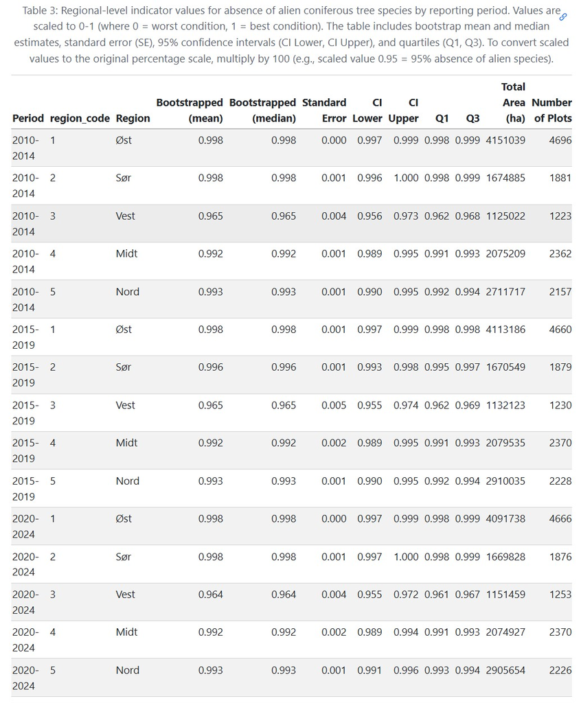

### 10.3 National results (aggregated with uncertainty)

Table 4: National-level indicator values for absence of alien coniferous tree species by reporting period. Values are scaled to 0-1 (where 0 = worst condition, 1 = best condition). The table includes bootstrap mean and median estimates, standard error (SE), 95% confidence intervals (CI Lower, CI Upper), and quartiles (Q1, Q3). To convert scaled values to the original percentage scale, multiply by 100 (e.g., scaled value 0.95 = 95% absence of alien species).

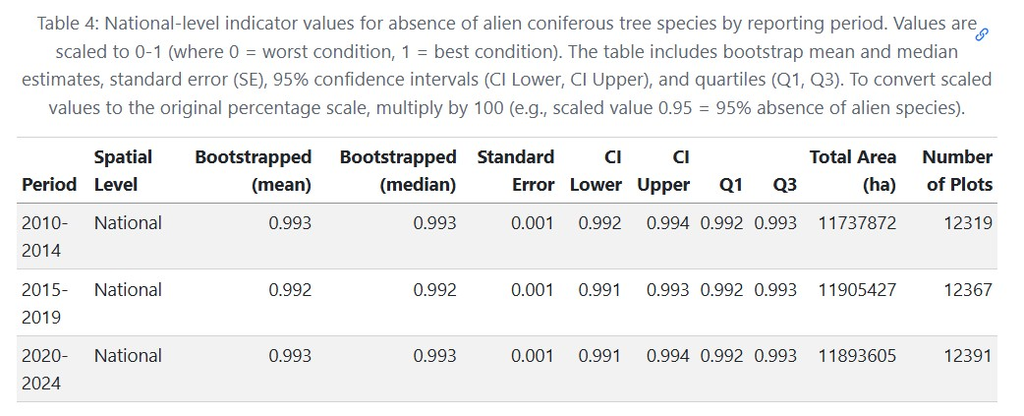

**Session Info**

This information is mainly aimed at developers that need to recreate the R environment that produced the html. Important note: this information is about the R session that was running when the html was rendered, and if some of the code chunks were not evaluated when the html was rendered, they may have been executed in a different environment.